# DSDA 1995

Data Science and Society using R

Lecture 11 | Tidy Data

## Plan for Today

- Explore data R with `Tidyverse`
- Discuss `tibbles`
- Discuss `Tidy` data

## Tibbles

- What is a tibble?
  - Tibbles are data frames
    - But they try and enhance the regular “old” data frame from base R
- To learn more
  - vignette(“tibble”)

## Creating Tibbles

- Tibbles are one of the unifying features of `tidyverse`
- Most other R packages use regular data frames, so you might want to coerce a data frame to a tibble
  - To do this, use `as_tibble()`

```r
as_tibble(iris)
```

```
# A tibble: 150 × 5
   Sepal.Length Sepal.Width Petal.Length Petal.Width Species
          <dbl>       <dbl>        <dbl>       <dbl> <fct>
 1          5.1         3.5          1.4         0.2 setosa
 2          4.9         3            1.4         0.2 setosa
 3          4.7         3.2          1.3         0.2 setosa
 4          4.6         3.1          1.5         0.2 setosa
 5          5           3.6          1.4         0.2 setosa
 6          5.4         3.9          1.7         0.4 setosa
 7          4.6         3.4          1.4         0.3 setosa
 8          5           3.4          1.5         0.2 setosa
 9          4.4         2.9          1.4         0.2 setosa
10          4.9         3.1          1.5         0.1 setosa
# ℹ 140 more rows
```

- You can create a new tibble from individual vectors with `tibble()`
  - `tibble()` automatically recycles inputs of length 1 and allows you to refer to variables that you just created

## Tibbles

- Let’s create a tibble

```r
tibble(
  x = 1:5,
  y = 1,
  z = x ^ 2 + y
)
```

```
# A tibble: 5 × 3
      x     y     z
  <int> <dbl> <dbl>
1     1     1     2
2     2     1     5
3     3     1    10
4     4     1    17
5     5     1    26
```

- Tibbles do much less than data frames
  - It never changes the type of the inputs (never converts strings to factors)
  - Never changes the name of variables
  - Never creates row names
- For example:

```r
tb <- tibble(
  `:)` = "smile",
  ` ` = "space",
  `2000` = "number"
)
```

- What do we notice?
  - Are these column names valid in base R?

## Tribbles

- Transposed Tibble (tribble)
  - Customized for data entry in code:column headings are defined by formulas
  - They start with `~`

```r
tribble(
  ~x, ~y, ~z,
  #--|--|----
  "a", 2, 3.6,
  "b", 1, 8.5
)
```

```
# A tibble: 2 × 3
  x         y     z
  <chr> <dbl> <dbl>
1 a         2   3.6
2 b         1   8.5
```

## Tibbles vs. data.frame

- There are two main differences between tibbles and data.frame
  - Printing
  - Subsetting

## Printing

- Tibbles have a refined print method that shows only the first 10 rows

```r
tibble(
  a = lubridate::now() + runif(1e3) * 86400,
  b = lubridate::today() + runif(1e3) * 30,
  c = 1:1e3,
  d = runif(1e3),
  e = sample(letters, 1e3, replace = TRUE)
)
```

```
# A tibble: 1,000 × 5
   a                   b              c      d e
   <dttm>              <date>     <int>  <dbl> <chr>
 1 2025-02-26 13:32:07 2025-03-12     1 0.374  o
 2 2025-02-25 21:46:55 2025-02-25     2 0.570  v
 3 2025-02-25 22:42:45 2025-02-26     3 0.0427 d
 4 2025-02-26 20:00:55 2025-03-01     4 0.556  n
 5 2025-02-26 03:57:22 2025-02-25     5 0.879  p
 6 2025-02-26 00:54:53 2025-03-25     6 0.166  l
 7 2025-02-26 19:24:04 2025-02-26     7 0.936  o
 8 2025-02-26 11:05:26 2025-03-01     8 0.401  z
 9 2025-02-25 22:58:19 2025-03-14     9 0.317  y
10 2025-02-26 17:32:48 2025-03-04    10 0.940  s
# ℹ 990 more rows
```

- Tibbles are designed so that you don’t accidentally overwhelm your console when you print large data frames

## Printing

- If you need more output than the default displays, then you can use the following options
  - `print()`
    - `n` controls the number of rows
    - `width` determines how many columns to display
- You can also control default print behavior by settings options
  - `options(tibble.print_max = n, tibble.print_min = m)`
    - if more than `n` rows, print only `m` rows
  - `options(tibble.print_min = Inf)`
    - To always show all rows
  - `options(tibble.width = Inf)`
    - To always print all columns, regardless of the width of the screen

## Subsetting

- Most of the subsetting tools that we have used this far generally subset the entire data frame
- How do we pull out just a single variable/value?
  - We can us `$` and `[[`
    - `[[` extracts by name or position
    - `$` extracts by name but is less typing

```r
df <- tibble(
  x = runif(5),
  y = rnorm(5)
)

# Extract by name
df$x
```

```
[1] 0.6644957 0.6492487 0.5519078 0.7367551 0.4483630
```

```r
df[["x"]]
```

```
[1] 0.6644957 0.6492487 0.5519078 0.7367551 0.4483630
```

```r
# Extract by position
df[[1]]
```

```
[1] 0.6644957 0.6492487 0.5519078 0.7367551 0.4483630
```

```r
df[[1,1]]
```

```
[1] 0.6644957
```

## Tidy Data

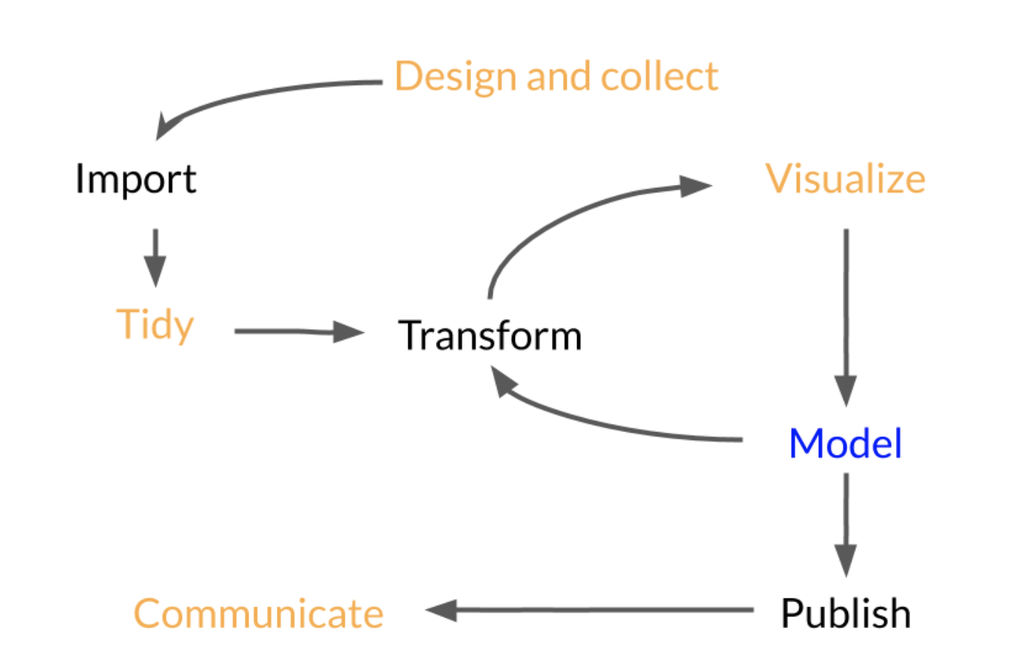

- What does it mean to tidy up data?
  - Structuring datasets to facilitate analysis (- Hadley Wickham)
- Tidy Rules
  - Each variable forms a column
  - Each observation forms a row
  - Each type of observational unit forms a table

## Tidy Data

- Visualizing the tidy rules

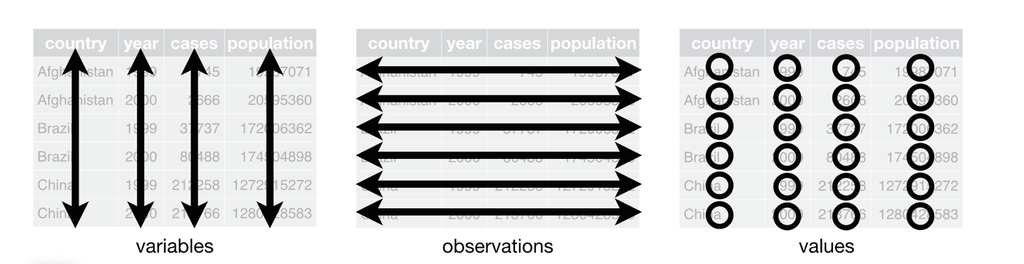

## Tidy Data

- How to tell if your data or untidy
  - Column headers are values instead of variable names
  - Multiple variables are stored in one column (e.g., City_State)
  - Variables are stored in both rows and columns
  - Multiple types of observational units are stored in the same table
  - A single observational unit is stored in multiple tables
  - Dataset is either too long or too wide

## Untidy Data

- Untidy data example

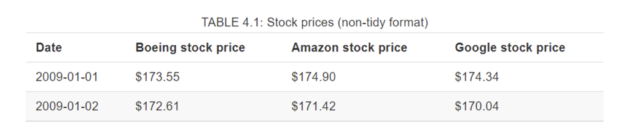

- Let’s clean it up!

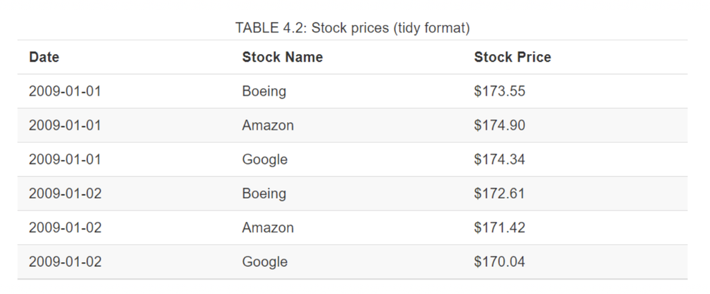

## Pivoting

- Most data that you encounter will be untidy
  - Most people aren’t familiar with the principles of tidy data, and it’s hard to derive them yourself unless you spend a lot of time working with data
  - Data is often organised to facilitate some use other than analysis. For example, data is often organised to make entry as easy as possible
- Things to look out for
  - One variable might be spread across multiple columns
  - One observation might be scattered across multiple rows
    - Usually, a dataset will only suffer from one of these problems
- Two functions that we will use
  - `pivot_longer()`
  - `pivot_wider()`

## Pivot Longer

- A common problem is a dataset where some of the column names are not names of variables, but values of a variable

```r
table4a
```

```
# A tibble: 3 × 3
  country     `1999` `2000`
  <chr>        <dbl>  <dbl>
1 Afghanistan    745   2666
2 Brazil       37737  80488
3 China       212258 213766
```

- To tidy a dataset like this, we need to pivot the offending columns into a new pair of variables

## Pivot Longer

- How do we utilize this function?
  - The set of columns whose names are values, not variables. In this example, those are the columns 1999 and 2000
  - The name of the variable to move the column names to. Here it is year
  - The name of the variable to move the column values to. Here it’s cases

```r
table4a |>
  pivot_longer(c(`1999`, `2000`), names_to = "year", values_to = "cases")
```

```
# A tibble: 6 × 3
  country     year   cases
  <chr>       <chr>  <dbl>
1 Afghanistan 1999     745
2 Afghanistan 2000    2666
3 Brazil      1999   37737
4 Brazil      2000   80488
5 China       1999  212258
6 China       2000  213766
```

- In the final result, the pivoted columns are dropped, and we get new year and cases columns
- Otherwise, the relationships between the original variables are preserved

## Pivot Longer

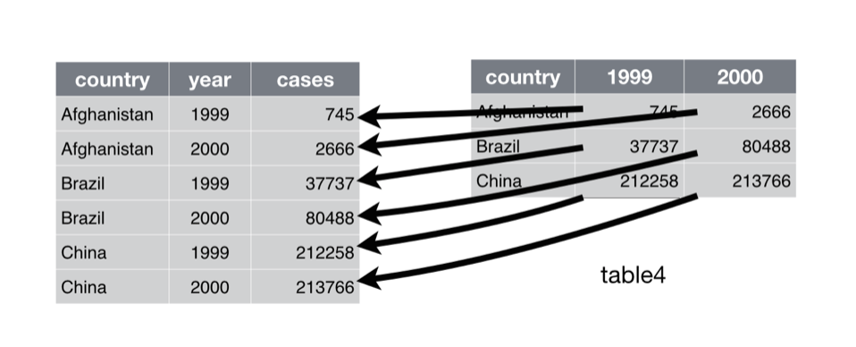

- pivot_longer() makes datasets longer by increasing the number of rows and decreasing the number of columns

## Pivot Wider

- pivot_wider() is the opposite of pivot_longer()
- You use it when an observation is scattered across multiple rows

```r
table2
```

```
# A tibble: 12 × 4
   country      year type            count
   <chr>       <dbl> <chr>           <dbl>
 1 Afghanistan  1999 cases             745
 2 Afghanistan  1999 population   19987071
 3 Afghanistan  2000 cases            2666
 4 Afghanistan  2000 population   20595360
 5 Brazil       1999 cases           37737
 6 Brazil       1999 population  172006362
 7 Brazil       2000 cases           80488
 8 Brazil       2000 population  174504898
 9 China        1999 cases          212258
10 China        1999 population 1272915272
11 China        2000 cases          213766
12 China        2000 population 1280428583
```

- To tidy this up, we first analyse the representation in similar way to `pivot_longer()`
  - The column to take variable names from. Here, it’s type
  - The column to take values from. Here it’s count

```r
table2 |>
    pivot_wider(names_from = type, values_from = count)
```

```
# A tibble: 6 × 4
  country      year  cases population
  <chr>       <dbl>  <dbl>      <dbl>
1 Afghanistan  1999    745   19987071
2 Afghanistan  2000   2666   20595360
3 Brazil       1999  37737  172006362
4 Brazil       2000  80488  174504898
5 China        1999 212258 1272915272
6 China        2000 213766 1280428583
```

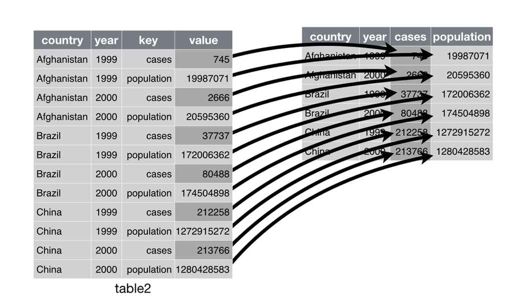